# Pan-cancer age-associated molecular changes

### Horizontal version (cancers as rows, pathways as columns)

Same data, ordering, and palettes as the vertical version above; only the matrices are transposed. Row names render on the right by default in pheatmap; flip them to the left in Illustrator if needed for layout alignment.

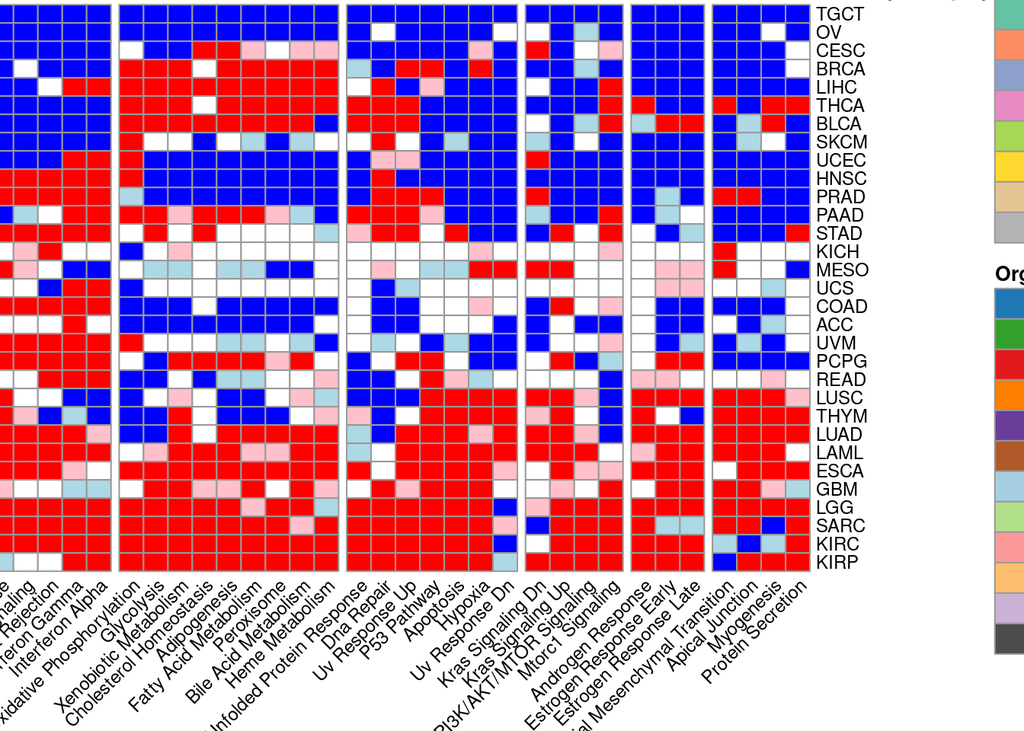

```r
threshold_matrix_h <- t(threshold_matrix)

# Pathway category factor in column order
column_categories <- factor(unname(row_categories), levels = pathway_category_levels)

# Annotations swap sides: pathway category becomes a column annotation,
# organ system becomes a row annotation.
category_df_h <- data.frame(
  `Pathway Category` = column_categories,
  row.names = colnames(threshold_matrix_h),
  check.names = FALSE
)

organ_df_h <- organ_df  # rownames = cancers, column = "Organ System"

# Gaps between pathway category groups (now between columns)
gaps_col <- gaps_row    # same cumulative counts, just applied to columns now

p_fig1C_h <- pheatmap::pheatmap(
  threshold_matrix_h,
  color             = heatmap_colors,
  breaks            = heatmap_breaks,
  cluster_rows      = col_hc,             # same cancer clustering as the vertical
  cluster_cols      = FALSE,              # pathways pre-ordered within categories
  gaps_col          = gaps_col,
  annotation_row    = organ_df_h,
  annotation_col    = category_df_h,
  annotation_colors = list(
    `Pathway Category` = category_palette,
    `Organ System`     = part1_imported_results$organ_palette
  ),
  annotation_legend = TRUE,
  legend            = FALSE,
  show_rownames     = TRUE,
  show_colnames     = TRUE,
  angle_col         = 45,
  fontsize          = 10,
  fontsize_row      = 9,
  fontsize_col      = 9,
  treeheight_row    = 8,
  treeheight_col    = 8,
  cellwidth         = 12,
  cellheight        = 9,
  main              = ""
)
```

```r
pdf(
  file   = file.path(fig_dir, "pathway_gsea_heatmap_horizontal.pdf"),
  width  = 13,
  height = 8
)
print(p_fig1C_h)
dev.off()
```

## Within- vs between-organ-system pairwise distance (per layer)

Per-pair distances are masked at the same per-pair feature-overlap floor used in the clustering averaging step. Pairs below the floor in a given layer are dropped from that layer’s plot and from its permutation test. Each layer is then evaluated on the cancers it measured, so the cancer set and the retained organ systems are defined per layer and the panels differ in the number of pairs they test. Significance is assessed by shuffling organ labels among that layer’s cancers, which holds the distance matrix fixed while breaking only the organ assignment.

```r
organ_lookup <- setNames(
  part1_imported_results$organ_annotations$Organ_System,
  part1_imported_results$organ_annotations$Project
)

# Masked pair-distance extraction. A pair is dropped (NA) for a layer if its
# per-pair feature overlap in that layer is below the clustering floor.
similarity_to_pair_df <- function(sim_mat, overlap_mat, organ_lookup,
                                  layer_label, min_overlap) {
  cancers <- colnames(sim_mat)
  d_mat   <- 1 - sim_mat
  d_mat[overlap_mat < min_overlap] <- NA

  ij <- which(upper.tri(d_mat), arr.ind = TRUE)

  tibble::tibble(
    cancer1  = cancers[ij[, 1]],
    cancer2  = cancers[ij[, 2]],
    organ1   = organ_lookup[cancers[ij[, 1]]],
    organ2   = organ_lookup[cancers[ij[, 2]]],
    distance = as.numeric(d_mat[ij]),
    layer    = layer_label
  )
}

layer_label_map <- c(
  "Methylation" = "Methylation",
  "RNAseq"      = "RNA-seq",
  "miRNA"       = "miRNA",
  "SCNA"        = "SCNA"
)

panel_levels <- unname(layer_label_map[pancancer_clustering$selected_layers])

min_overlap <- pancancer_clustering$thresholds$MIN_PAIR_OVERLAP

per_layer_pairs <- purrr::imap_dfr(
  pancancer_clustering$similarity_by_layer,
  function(sim, layer_id) {
    similarity_to_pair_df(
      sim_mat      = sim,
      overlap_mat  = pancancer_clustering$pair_overlap_by_layer[[layer_id]],
      organ_lookup = organ_lookup,
      layer_label  = layer_label_map[[layer_id]],
      min_overlap  = min_overlap
    )
  }
)

# Per-layer eligibility. Each layer is tested on the cancers it measured, so
# the cancer set comes from that layer's own pairs rather than from the
# clustered cancer set. Masking runs first: a pair below the overlap floor is
# already NA here, so a cancer whose pairs are all masked does not enter the
# layer. Organ systems with fewer than two cancers in the layer contribute no
# within-organ pairs and are dropped from that layer.
eligible_by_layer   <- list()
all_pairs_by_layer  <- list()
filter_summary_list <- list()

for (lyr in panel_levels) {
  layer_pairs <- per_layer_pairs %>%
    dplyr::filter(layer == lyr)

  layer_pairs_kept <- layer_pairs %>%
    dplyr::filter(is.finite(distance), !is.na(organ1), !is.na(organ2))

  layer_cancers     <- union(layer_pairs_kept$cancer1, layer_pairs_kept$cancer2)
  layer_organ_n     <- table(organ_lookup[layer_cancers])
  layer_multi_organ <- names(layer_organ_n[layer_organ_n >= 2])

  eligible_by_layer[[lyr]] <- layer_cancers[
    organ_lookup[layer_cancers] %in% layer_multi_organ
  ]

  all_pairs_by_layer[[lyr]] <- layer_pairs_kept %>%
    dplyr::filter(
      cancer1 %in% eligible_by_layer[[lyr]],
      cancer2 %in% eligible_by_layer[[lyr]]
    )

  filter_summary_list[[lyr]] <- tibble::tibble(
    layer                 = lyr,
    n_cancers_in_layer    = length(union(layer_pairs$cancer1, layer_pairs$cancer2)),
    n_cancers_after_floor = length(layer_cancers),
    n_cancers_eligible    = length(eligible_by_layer[[lyr]]),
    n_organ_systems       = length(layer_multi_organ),
    n_pairs_in_layer      = nrow(layer_pairs),
    n_pairs_below_floor   = sum(!is.finite(layer_pairs$distance)),
    n_pairs_tested        = nrow(all_pairs_by_layer[[lyr]])
  )
}

all_pairs <- dplyr::bind_rows(all_pairs_by_layer) %>%
  dplyr::mutate(
    pair_type = ifelse(organ1 == organ2, "Within Organ", "Between Organ"),
    pair_type = factor(pair_type, levels = c("Within Organ", "Between Organ")),
    layer     = factor(layer, levels = panel_levels)
  )

filter_summary <- dplyr::bind_rows(filter_summary_list) %>%
  dplyr::mutate(layer = factor(layer, levels = panel_levels))

reactable(filter_summary)
```

| layer | n_cancers_in_layer | n_cancers_after_floor | n_cancers_eligible | n_organ_systems | n_pairs_in_layer | n_pairs_below_floor | n_pairs_tested |
| --- | --- | --- | --- | --- | --- | --- | --- |
| Methylation | 30 | 30 | 24 | 6 | 435 | 0 | 276 |
| RNA-seq | 31 | 31 | 25 | 6 | 465 | 0 | 300 |
| miRNA | 30 | 30 | 23 | 5 | 435 | 0 | 253 |
| SCNA | 32 | 31 | 27 | 7 | 496 | 95 | 300 |

```r
sig_label <- function(p) {
  dplyr::case_when(
    p < 0.01  ~ "**",
    p < 0.05  ~ "*",
    TRUE      ~ "n.s."
  )
}

N_PERM    <- 10000
PERM_SEED <- 20260731

empirical_two_sided_p <- function(observed, null) {
  null <- null[is.finite(null)]

  p_upper <- (1 + sum(null >= observed)) / (length(null) + 1)
  p_lower <- (1 + sum(null <= observed)) / (length(null) + 1)

  min(1, 2 * min(p_upper, p_lower))
}

rank_permutation_p <- function(distance, cancer1, cancer2, organ1, organ2,
                               eligible_cancers, perm_org_mat) {
  within  <- organ1 == organ2
  between <- !within
  ranks   <- rank(distance, ties.method = "average")

  observed <- mean(ranks[between]) - mean(ranks[within])

  idx1 <- match(cancer1, eligible_cancers)
  idx2 <- match(cancer2, eligible_cancers)

  if (anyNA(idx1) || anyNA(idx2)) {
    stop("Cancer matching failed in permutation test.")
  }

  within_perm <-
    perm_org_mat[idx1, , drop = FALSE] ==
    perm_org_mat[idx2, , drop = FALSE]

  n_within_perm  <- colSums(within_perm)
  n_between_perm <- length(distance) - n_within_perm
  valid           <- n_within_perm > 0 & n_between_perm > 0

  total_rank      <- sum(ranks)
  within_rank_sum <- colSums(within_perm * ranks)

  null <- rep(NA_real_, ncol(perm_org_mat))
  null[valid] <-
    (total_rank - within_rank_sum[valid]) / n_between_perm[valid] -
    within_rank_sum[valid] / n_within_perm[valid]

  empirical_two_sided_p(observed, null)
}

set.seed(PERM_SEED)

# Organ labels are shuffled among the cancers eligible in each layer, so each
# layer's null preserves its own organ-system sizes.
perm_org_by_layer <- list()

for (lyr in panel_levels) {
  layer_organs <- unname(organ_lookup[eligible_by_layer[[lyr]]])
  perm_org_by_layer[[lyr]] <- vapply(
    seq_len(N_PERM),
    function(b) sample(layer_organs, size = length(layer_organs), replace = FALSE),
    FUN.VALUE = layer_organs
  )
}

perm_per_layer <- all_pairs %>%
  dplyr::group_by(layer) %>%
  dplyr::summarise(
    p_value = rank_permutation_p(
      distance         = distance,
      cancer1          = cancer1,
      cancer2          = cancer2,
      organ1           = organ1,
      organ2           = organ2,
      eligible_cancers = eligible_by_layer[[as.character(layer[1])]],
      perm_org_mat     = perm_org_by_layer[[as.character(layer[1])]]
    ),
    n_within       = sum(pair_type == "Within Organ"),
    n_between      = sum(pair_type == "Between Organ"),
    median_within  = median(distance[pair_type == "Within Organ"]),
    median_between = median(distance[pair_type == "Between Organ"]),
    .groups        = "drop"
  ) %>%
  dplyr::mutate(
    sig_label = sig_label(p_value),
    layer     = factor(layer, levels = panel_levels)
  )

utils::write.csv(
  perm_per_layer,
  file = file.path(fig_dir, "within_vs_between_organ_summary.csv"),
  row.names = FALSE
)

reactable(perm_per_layer)
```

| layer | p_value | n_within | n_between | median_within | median_between | sig_label |
| --- | --- | --- | --- | --- | --- | --- |
| Methylation | 0.0337966203379662 | 43 | 233 | 0.789269901907304 | 0.870420093103576 | * |
| RNA-seq | 0.0005999400059994 | 46 | 254 | 0.960673820030778 | 1.00616085449432 | ** |
| miRNA | 0.0025997400259974 | 45 | 208 | 0.929166867870269 | 0.984999550326933 | ** |
| SCNA | 0.280571942805719 | 48 | 252 | 0.88096461162618 | 1.00669988624208 | n.s. |

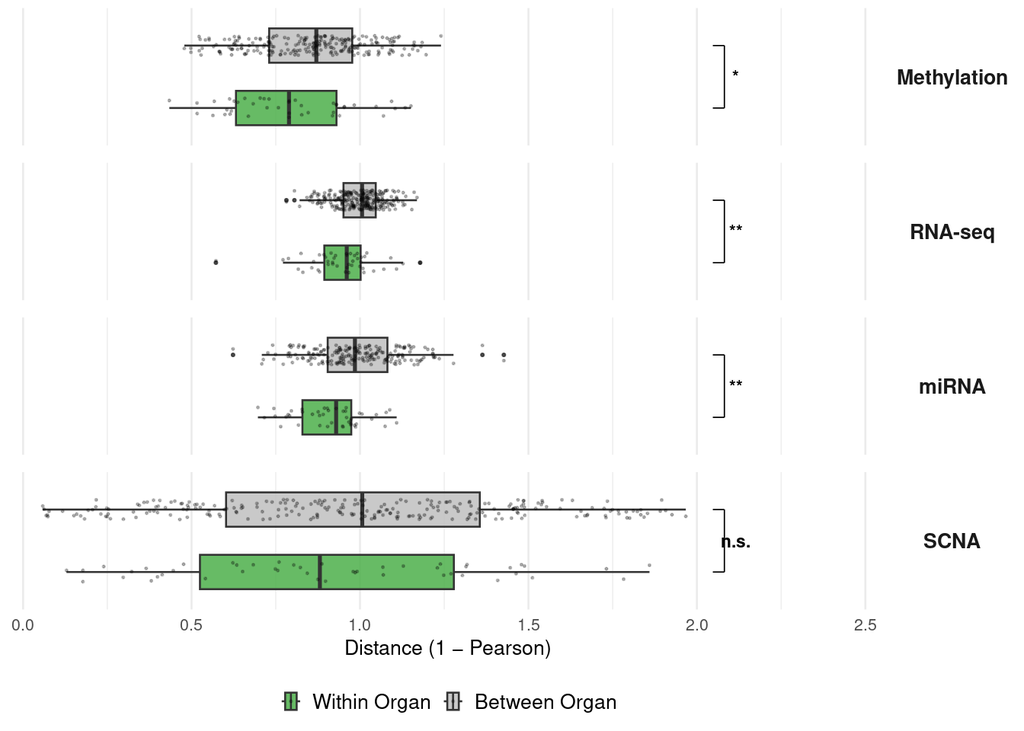

```r
x_global_max <- max(all_pairs$distance, na.rm = TRUE)
x_global_min <- min(all_pairs$distance, na.rm = TRUE)
x_pad        <- (x_global_max - x_global_min) * 0.06

sig_anno_df <- perm_per_layer %>%
  dplyr::mutate(x_position = x_global_max + x_pad)

pair_fill_values <- c("Within Organ" = "#4DAF4A", "Between Organ" = "grey75")

p_fig1D <- ggplot(all_pairs, aes(x = distance, y = pair_type, fill = pair_type)) +
  geom_boxplot(outlier.size = 0.4, width = 0.55, alpha = 0.85) +
  geom_jitter(height = 0.16, size = 0.3, alpha = 0.25) +
  geom_segment(
    data = sig_anno_df,
    aes(x = x_position, xend = x_position, y = 1, yend = 2),
    inherit.aes = FALSE, linewidth = 0.3
  ) +
  geom_segment(
    data = sig_anno_df,
    aes(x = x_position - x_pad * 0.3, xend = x_position, y = 1, yend = 1),
    inherit.aes = FALSE, linewidth = 0.3
  ) +
  geom_segment(
    data = sig_anno_df,
    aes(x = x_position - x_pad * 0.3, xend = x_position, y = 2, yend = 2),
    inherit.aes = FALSE, linewidth = 0.3
  ) +
  geom_text(
    data = sig_anno_df,
    aes(x = x_position + x_pad * 0.3, y = 1.5, label = sig_label),
    inherit.aes = FALSE, size = 3, fontface = "bold"
  ) +
  scale_fill_manual(name = NULL, values = pair_fill_values) +
  scale_x_continuous(expand = expansion(mult = c(0.05, 0.22))) +
  facet_wrap(~ layer, ncol = 1, strip.position = "right") +
  labs(
    x = "Distance (1 \u2212 Pearson)",
    y = NULL
  ) +
  theme_minimal(base_size = 10) +
  theme(
    legend.position    = "bottom",
    legend.key.size    = unit(0.4, "cm"),
    legend.text        = element_text(size = 10),
    panel.grid.major.y = element_blank(),
    axis.text.y        = element_blank(),
    axis.ticks.y       = element_blank(),
    strip.text.y       = element_text(size = 10, face = "bold", angle = 0),
    strip.background   = element_blank(),
    panel.spacing      = unit(0.3, "cm"),
    plot.margin        = margin(4, 4, 4, 4)
  )

print(p_fig1D)
```

```r
ggsave(
  filename = file.path(fig_dir, "within_between_combined.pdf"),
  plot     = p_fig1D,
  width    = 4,
  height   = 5,
  units    = "in"
)

scna_pairs <- per_layer_pairs[per_layer_pairs$layer == "SCNA", ]
scna_kept  <- scna_pairs[is.finite(scna_pairs$distance), ]

setdiff(
  union(scna_pairs$cancer1, scna_pairs$cancer2),
  union(scna_kept$cancer1, scna_kept$cancer2)
)
```

```
## [1] "TCGA-THCA"
```